# Microbiome data manipulation and visualization in R

version June 14, 2018

## Workshop outline

- Introduction to R on a cluster
- Microbiome data manipulation in RStudio using the [tidyverse](https://www.tidyverse.org/)
- Microbiome data visualization in RStudio using [phyloseq](https://www.bioconductor.org/packages/release/bioc/html/phyloseq.html)
- All data and materials are available at https://github.com/EDUCE-UBC/workshops/tree/master/microbiome_summer_school

## Why R/RStudio?

- Open source
- Command line and GUI options
- Reproducible research and version control (Rmarkdown, Rnotebook, etc.)
- Huge community of developers around the world
- Custom packages, many of which are applicable to microbiome data analysis
  - 28+ [CRAN](https://cran.r-project.org/web/packages/available_packages_by_name.html) package titles contain the word "DNA"
  - Dozens more on [Bioconductor](https://www.bioconductor.org/)

## Data description

- Part of an on-going oceanographic time series program in Saanich Inlet
- Geochemical measurements at various depths taken approximately monthly from 2006 to 2014
- 16S Illumina amplicon sequencing of 7 depths in August 2012

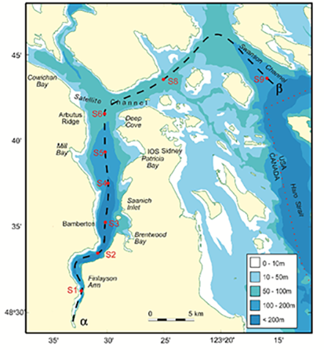

**Figure 1.** Map of Saanich Inlet indicating conventional sample collection stations (S1-S9). Data used in this workshop is sourced from S3.

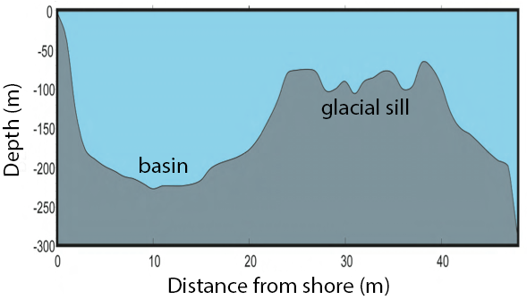

**Figure 2.** Structure of Saanich Inlet. The glacial sill restricts water circulation into and out of the lower depth of the inlet basin.

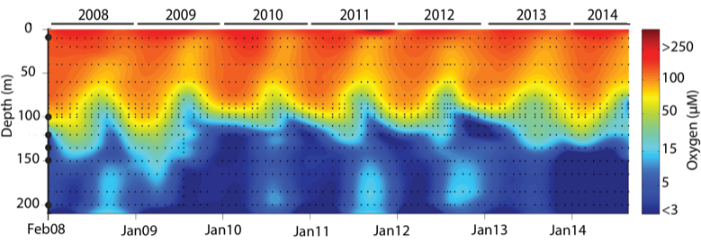

**Figure 3.** Contour plot of water column oxygen concentrations over multiple years in the time series. Note the recurring pattern of oxygen decline below 100 m depth intervals followed by seasonal renewal events in late Summer into early Fall carrying more oxygenated waters into the Inlet.

## Data in this workshop

- 16S Illumina amplicon sequencing of 7 depths in Saanich Inlet (S3) from August 2012
- Corresponding geochemical data from 16 depths
  - Oxygen: O<sub>2</sub>
  - Nitrogen: NO<sub>3</sub>, NH<sub>4</sub>, NO<sub>2</sub>, N<sub>2</sub>O
  - Phosphorous: PO<sub>4</sub>
  - Sulfur: H<sub>2</sub>S
  - Carbon: CH<sub>4</sub>
  - Other: temperature, salinity

## Microbial questions

How do microbial communities change with depth or nutrient availability?

Is there a pattern in microbial communities in response to seasonal changes?

How can this inform our predictions for how ocean microbial communities will change with climate change (*i.e.* reduced oxygen and nitrogen, higher temperatures)?

## Phylogenetic answers?

- Sequences clustered into 97% operational taxonomic units (OTUs) as a proxy for microbial species
- Does not fully capture relatedness of "species"
- Phylogenetic approaches compare "species" at the sequence level
- Such analyses require a phylogenetic tree
  - This calculation is our current mission on cedar!

## R on the cluster

## More workshops

[figure not shown]

- **Next week**: Exploring the phylogenetic composition of microbiomes
- **July**: Reproducible research in R and Git

For more info and future workshops, see http://ecoscope.ubc.ca/events/

To contact Kim, email kadm@mail.ubc.ca